# The 2-Transition Subcomplex and the 2-Transition Surface

Glenn Davis

2025-08-31

Throughout this vignette, $Z$ is a zonohedron such that none of its generators $L(e_1),...,L(e_n)$ are 0, and no generator is a multiple of another. Equivalently, we assume that matroid of $Z$ is simple. For more discussion of zonohedra, see the Zonotopes vignette.

Given such a zonohedron $Z$, and a cyclic ordering of the generators of $Z$, there is a surface contained in $Z$, which may coincide with $\partial Z$, but in general does not. In this vignette we give a careful definition of this *2-transition surface*, give some examples, and explain some of the relevant functions in the **zonohedra** package for processing this surface. Points in the 2-transition surface are analogous to the reflectance spectra of *Schrödinger colors*. Points in $\partial Z$ are analogous to the reflectance spectra of *optimal colors*, see [8], [5], and especially [10].

Featured functions in this vignette are: `raytrace2trans()`, `transitionsdf()`, and `plothighertrans()`.

Given $x_1,x_2 \in \mathbb{R}^n$, $[x_1,x_2]$ denotes the line segment from $x_1$ to $x_2$.

```r
library(zonohedra)
```

# 1 The Unit Cube $Q^n$

We abbreviate $Q^n := [0,1]^n$, i.e. the $n$-cube. So $Q^n$ is all points $x = (\alpha_1, ... , \alpha_n)$ where all $\alpha_i \in [0,1]$. For this vignette we assume $n \ge 3$.

A *vertex* of $Q^n$ is a point where all $\alpha_i = 0 ~ \textrm{or} ~ 1$; there are $2^n$ vertices. If two vertices differ by exactly one coordinate, they are the endpoints of an *edge*, and the “free” coordinate parameterizes the edge. There are $n 2^{n-1}$ edges. If four vertices differ by two coordinates, they are the vertices of a *square*, and the two “free” coordinates parameterize the square. There are $\binom{n}{2} 2^{n-2}$ squares. In the familiar case when $n{=}3$, there are 8 vertices, 12 edges, and 6 squares. Note that $(\alpha_1, ... , \alpha_n) \in \partial Q^n$ iff some $\alpha_i =$ 0 or 1. Thus vertices, edges, and squares are all subsets of $\partial Q^n$.

The *standard involution* $\rho: Q^n \to Q^n$ is the map $(\alpha_1, ... , \alpha_n) ~ \mapsto ~ (1-\alpha_1, ... , 1-\alpha_n)$. It is clear that $\rho$ maps a vertex to an *antipodal vertex*, Similarly, there are pairs of *antipodal edges* and *antipodal squares*. $\rho$ has a unique fixed point $(1/2, ... ,1/2)$, which is the center of symmetry.

# 2 The 2-Transition Subcomplex $Q_2^n \subset Q^n$

This section treats the *2-transition subcomplex* of $Q^n$ with $n \ge 3$, which we denote by $Q^n_2$. We define it in three ways.

**Definition 1:**  
Visualize the indexes $1, ... ,n$ as points on the circle, like beads in a necklace, or the $n$ roots of unity. Different points $i \ne j$ divide the other points into 2 contiguous “arcs” (one of them may be empty). Define $(\alpha_1, ... , \alpha_n) \in Q^n_2$ iff there are $i \ne j$, so that $\alpha_k = 0$ for $k$ in one arc and $\alpha_k = 1$ for $k$ in the other arc.

There are 2 ways to choose 0 and 1, so as $\alpha_i$ and $\alpha_j$ vary, they “sweep out” 2 disjoint and antipodal squares in $Q^n$. The total number of these *2-transition squares* is $n(n-1)$. $Q^n_2$ is the union of these squares, joined along their edges.

It is helpful to visualize points in the unit cube as bar graphs. Here are four points in $Q^{10}_2$, with 2 transitions:

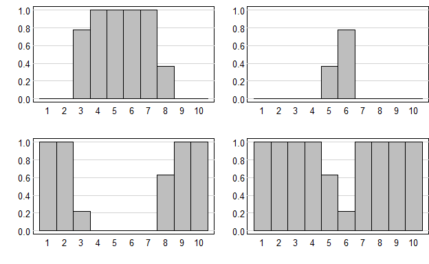

Figure 2.1 four points in the 2-transition complex, visualized with bar graphs

```r
mybarplot <- function( x )  {
n = length(x)
plot( c(0,n), c(0,1), type='n', tcl=0, las=1, xaxt='n', xlab='', ylab='', mgp=c(3,0.25,0) )
grid( nx=NA, ny=NULL, lty=1 )
barplot( x, names.arg=1:n, space=0, add=T, yaxt='n', mgp=c(3,0.25,0) )
}

x1 = numeric(10) ; x1[ c(3,8) ] = exp( c(-0.25,-1) ) ; x1[ 4:7 ] = 1
x2 = numeric(10) ; x2[ c(5,6) ] = exp( c(-1,-0.25) )

oldpar = par( mfrow=c(2,2)  , omi=c(0,0,0,0), mai=c(0.45,0.5,0.1,0) )
mybarplot( x1 )   ; mybarplot( x2 )     #  row #1
mybarplot( 1-x1 ) ; mybarplot( 1-x2 )   #  row #2
```

```r
par( oldpar )
```

The special vertices $(0,...,0)$ and $(1,...,1)$ are in $Q^n_2$ by this definition, although they technically have no transitions. Also, if $\alpha_i = 0$ except for one $i$, that point is *also* in $Q^n_2$ because it is in an edge of one of the above-defined squares.

Note that $Q^3_2 = \partial Q^3$, i.e. every point in the boundary of $Q^3$ is a 2-transition point.

**Definition 2:**  
This definition views a 2-transition point as a special discrete projection of a 2-transition function defined on a circle.

Given $n$, define $n+1$ points, $\beta_i := i + 1/2$ for $i = 0,...,n$, and $n$ intervals $I_i := [\beta_{i-1},\beta_i]$ = $[i-1/2,i+1/2]$ for $i = 1,...,n$. These intervals have length 1 and are a partition of $[1/2,n+1/2]$.

Let $J_2$ be the set of all (step) functions on $[\beta_0,\beta_n]$ that take the values 0 or 1 and have two transitions or no transitions (jumps). We identify the endpoints $\beta_0$ and $\beta_n$ to form a circle, so if the functions values at $\beta_0$ and $\beta_n$ are different, then this is considered to be a transition. Equivalently $J_2$ is the set of all indicator functions $\mathbf{1}_A$ where $A$ is an arc in the circle. We allow the arc to be empty (the function is identically 0), or the entire circle (the function is identically 1). Define a function $p()$
$$\begin{equation}
p : J_2 \twoheadrightarrow Q^n ~~~ \text{by} ~~~ p(f) :=
(\alpha_1,\ldots,\alpha_n) ~~~ \text{where} ~~~ \alpha_i
:= \int_{I_i} f(\lambda) \, d\lambda
\end{equation}$$
Note that $\alpha_i$ is the mean of $f$ on $I_i$. So if $f$ is identically 1 on $I_i$, then $\alpha_i = 1$ in $p(f)$. And the same is true with 1 replaced by 0. But if $f$ has a jump in $I_i$, then $\alpha_i$ can be anywhere in $[0,1]$ depending on where the jump occurs. If there is exactly one jump in $I_i$, then the location of the jump is uniquely determined by $\alpha_i$. But if there are two jumps in $I_i$, then the 2 jump locations are **not** determined by $\alpha_i$. It only determines the distance between the jumps, so both can be translated a little bit and not change $\alpha_i$. Thus, $p$ is *not* injective.

Here are plots with 2 examples:

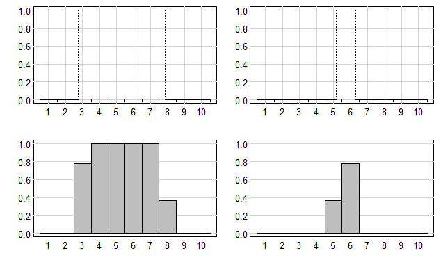

Figure 2.2

```r
mystepplot <- function( x )  {
# assumption: x is Type I
n = length(x)
plot( c(1/2,n+1/2), c(0,1), type='n', tcl=0, las=1, xlab='', ylab='', lab=c(n,5,7), mgp=c(3,0.25,0) )
grid( lty=1 )
beta = seq(1/2,n+1/2,by=1) ; segments( beta, 0, beta, -0.02 )
ij = which( 0<x & x<1)  ;  lambda = ij + c(1/2 - x[ ij[1] ], x[ ij[2] ] - 1/2)
lines( c(0.5,lambda[1]), c(0,0) ) ; lines(lambda,c(1,1)) ; lines( c(lambda[2],n+1/2), c(0,0) )
segments( lambda, c(0,0), lambda, c(1,1), lty=3 )
}

oldpar = par( mfrow=c(2,2), omi=c(0,0,0,0), mai=c(0.45,0.5,0.1,0) )
mystepplot( x1 ) ; mystepplot( x2 )     #  row #1
mybarplot( x1 ) ; mybarplot( x2 )       #  row #2
```

```r
par( oldpar )
```

The 1st plot shows a function $f \in J_2$ with jumps in intervals $I_3$ and $I_8$. The plot below it shows $p(f) \in Q^{10}_2$. The 2nd plot shows a function $f \in J_2$ with jumps in intervals $I_5$ and $I_6$. The plot below it shows $p(f) \in Q^{10}_2$. In the 1st row, the sequence $\beta_i$ (all of them half-integers) is marked with small tick marks.

We now define $Q^n_2$ to be the image of $p()$; i.e. $Q^n_2 := p(J_2)$. It is straightforward to show that **Definition 2** and **Definition 1** are equivalent.

Now we look at $J_2$ in more detail. Every function in $J_2$ is integrable, so we can think of $J_2 \subset L^1(\mathbb{S}^1)$, which is the space of integrable functions on the circle $\mathbb{S}^1$.

**Theorem** With the $L^1$ topology, $J_2$ is homeomorphic to the 2-sphere $\mathbb{S}^2$.

**Proof** Denote the 2 functions in $J_2$ that are identically 0 or 1 by $f_0$ and $f_1$. For a point in $J_2 - \{f_0, f_1\}$, the corresponding arc $A$ is non-trivial, and so the midpoint of the arc is a well-defined point in $\mathbb{S}^1$. The length of the arc is in the open interval $(0,2\pi)$. This assignment gives a homeomorphism from $J_2 - \{f_0 , f_1\}$ to the open cylinder $U := \mathbb{S}^1 \times (0,2\pi)$. Note that as two points in $J_2$ get closer to $f_0$, they get closer to each other in the $L^1$ metric; and similarly for $f_1$. So if bottom and top boundaries of $U$ are each collapsed to a point, and $f_0$ and $f_1$ are mapped to those two points, it continuously extends the above homeomorphism to all of $J_2$ and to the cylinder with collapsed boundaries, which is just a 2-sphere $\mathbb{S}^2$. $\square$

Later, we will see that $Q^n_2$ is *also* homeomorphic to $\mathbb{S}^2$. But the above mapping $p : J_2 \twoheadrightarrow Q^n_2$ is *not* a homeomorphism, because we observed above that $p$ is *not* injective.

**Definition 3:**  
This definition works directly with vertices and squares of $Q^n$. A *2-transition vertex* is one with a single circular run of 0s, and a single circular run of 1s. A run is allowed to empty, and this yields the vertex of all 0s and all 1s. A *2-transition square* is a square whose 4 vertices are all 2-transition vertices. Note that the center of the square has exactly 2 coordinates with value 1/2, and the other values are a circular arc of 0s and an arc of 1s. We now define $Q^n_2$ to be the union of all these 2-transition squares. It is an example of a cubical subcomplex of $Q^n$. Once again, it is straightforward to show that **Definition 3** and **Definition 1** are equivalent.

For an $x := (\alpha_1,...,\alpha_n) \in Q^n_2$, we define the *level* of $x$ be the number of $\alpha_i$’s that equal $1$. The level varies from 0 to $n$. The level is constant on the interior of an edge and the interior of a square. We define the *level* of a square to be the level on the interior. The level of a square varies from 0 to $n{-}2$. It is helpful to think of level=0 squares at the “bottom” of the subcomplex, and level=$n{-}2$ squares at the “top”.

So we know that $Q^n_2$ is a union of squares, but what does it “look like”, and what is its topology? We claim that $Q^n_2$ is a 2-sphere $\mathbb{S}^2$. In the case of $n{=}3$ this is easy to see, since $Q^3_2$ = $\partial Q^3$.

In general, first consider all the 2-transition squares with level=0. It is straighforward to show that such a square has 0 as a vertex, and it has 2 vertices with level=1 and one vertex with level=2. Each edge from 0 to a level 1 vertex is shared by two of the squares, and so the squares are arranged in circular fashion around 0. Their union is a topological disk $\mathbb{D}^2$ at the “bottom”. Similarly, the level=$n{-}2$ squares form a disk at the “top”.

Now consider squares with fixed level $\mathcal{l}$ with $0 < \mathcal{l} < n{-}2$. It is easy to show that in each square, both of the level=$\mathcal{l}{+}1$ vertices are in one other square, so the level $\mathcal{l}$ squares form a “necklace of $n$ diamonds”. These $n{-}3$ necklaces are stacked on top of each other to form a cylinder, and the cylinder is capped at bottom and top to form the 2-sphere $\mathbb{S}^2$. We now verify the square count in $Q^n_2$; $n + n(n{-}3) + n = n(n-1)$ which is correct.

The following figure is a helpful visualization.

```r
rgl::par3d( zoom=0.7 )
rgl::mfrow3d( 1, 2 )
zono =  polarzonohedron(9)
plot2trans( zono )
rgl::next3d()
plot2trans( zono, level=c(0,4,7) )
rgl::rglwidget( webgl=TRUE )
```

[interactive chart not shown]

Figure 2.3 [these are interactive WebGL widgets]

This figure plots the image of $Q^9_2$ in $\mathbb{R}^3$ under a suitable linear map. The squares are distorted into parallelograms. The figure on the left draws the full subcomplex, and the one on the right only draws levels 0, 4, and 7. The “necklace of 9 diamonds” at level=4 is easily visible. The black dot is the image of $(0,...,0)$, and the white dot is the image of $(1,...,1)$.

More about these linear maps is given in the next section.

# 3 The 2-Transition Surface $S_2 \subset Z \subset \mathbb{R}^3$

Let the zonohedron $Z := L(Q^n)$, where $L : \mathbb{R}^n \twoheadrightarrow \mathbb{R}^3$ is a surjective linear map. From now on we assume that $Z$ is *pointed*, which means that 0 is a vertex of $Z$.

Let $S_2 := L(Q^n_2)$ be the image of the 2-transition subcomplex $Q^n_2$. Since the subcomplex is a union of squares glued on the edges to form a 2-sphere $\mathbb{S}^2$, $S_2$ is a union of parallelograms glued on the edges. $S_2$ is a tesselated surface, but may not be a sphere because it may have self-intersections.

We are mainly interested in the case that there are *no* self-intersections, and there is a precise way to state this. Let $L_2$ be the restriction of $L$ to $Q^n_2$. So $L_2 : Q^n_2 \to \mathbb{R}^3$ is the composition of the inclusion $Q^n_2 \subset \mathbb{R}^n$ followed by $L$. The surface has no self-intersections iff $L_2$ is injective.

For example, in the previous figure $S_2$ does **not** have self-intersections and is a topological 2-sphere. $L_2$ is injective.

If $L_2$ is injective, then it is well-known ([1], [7] p. 117, and [2] p. 161) that $S_2$ divides $\mathbb{R}^3$ into an inside region and an outside region whose intersection is $S_2$. Moreover, the inside region is homeomorphic to a closed ball, and $S_2$ is the boundary of that ball.

Since $Q^n_2 \subset Q^n$, $S_2 = L(Q^n_2) \subset L(Q^n) = Z$. We emphasize that $S_2$ is a surface, and $Z$ is a solid. We also emphasize that $S_2$ depends intimately on the order of the generators, and $Z$ does not depend on the order at all.

# 4 Polygons

A polygon for us is more than just a subset of the plane. A *polygon* is a finite and cyclically ordered set of distinct *vertices*, plus the line segments that connect the vertices in cyclic order. The line segments are called the *edges*. The union of the edges is a subset of the plane, but two different sets of vertices can generate the same subset - the vertices matter.

A *simple polygon* is a polygon whose edges do not intersect, except at corresponding endpoints; i.e. the polygon has no self-intersections. By the *Jordan Curve Theorem*, a simple polygon, as just a set, has an inside region and an outside region, and both are connected. Note that a non-simple polygon may also have a connected inside region; it might “double-back” on itself within an edge, and then proceed forward again.

A *convex polygon* is a polygon with an inside region that is convex.

There is an equivalent definition of polygon using functions. Let $U_n$ be the set of $n$’th root of unity on the unit circle in $\mathbb{C}$, plus the edges connecting these vertices in order. So $U_n$ is sort of a *quintessential* or *template* polygon. A general polygon is a function $f : U_n \to \mathbb{R}^2$ which is injective *on the vertices* (the image vertices are distinct) and linear *on each edge*. Since $f$ is injective on the vertices, it is also injective on each edge; one can think of $f$ as a *piecewise-linear immersion* of $U_n$. A polygon defined this way is *simple* iff $f$ is injective.

# 5 The Generator Polygon $P$

Since $Z$ is pointed, there is a plane $K$ in $\mathbb{R}^3$ that has 0 in one open halfspace, and all the generators of $Z$ in the other open halfspace. This “cutting” hyperplane intersects $S_2$ in a polygon. Each vertex of the polygon is the intersection of $K$ and the segment from 0 to a generator. The cyclic order of its vertices is inherited from the order of the generators. We call this the *generator polygon* and let $P := K \cap S_2$ denote it.

$P$ may not be a simple polygon in general; it may have self-intersections.

Since there can be many cutting hyperplanes $K$, $P$ is only defined up to a projective transformation. In colorimetry for example, there are three chromaticity diagrams, from 1931, 1960, and 1976. They are all generator polygons for the same set of generators, and the 3 polygons differ by projective transformations, see [4].

# 6 Parallelograms in $S_2$ and $\partial Z$

Given $\partial Z$ and $S_2$ as above, the goal in this section is to show that each is a union of $n(n{-}1)$ parallelograms, and to set up a 1-1 correspondence between the parallelograms in $S_2$ and those in $\partial Z$. Each parallelogram will also be assigned a unit normal in such a way that corresponding parallelograms have the same normal.

First consider $\partial Z$. If a facet of $Z$ is not a parallelogram, let it be tiled with the *standard tiling* by parallelograms, see the Zonotopes vignette. Given an unordered pair $\{ i,j \}$ with $1 \le i , j \le n$ and $i \ne j$, there are 2 antipodal parallelograms in $\partial Z$. The edges of both parallelograms are the generators $L(e_i)$ and $L(e_j)$. If $\mathcal{P}$ is one of those parallelograms, we know that $\mathcal{P}$ is the image of some square in $Q^n$. The following Lemma algebraically characterizes which squares map to a parallelogram $\mathcal{P} \subset \partial Z$.

**Lemma:** Let $\Sigma$ be a square in $Q^n$. By definition $\Sigma$ is determined by an unordered pair $\{ i,j \}$ and for all $k \notin \{ i,j \}$, an assignment of $\alpha_k$ to either 0 or 1. The coordinates $\alpha_i$ and $\alpha_j$ are ‘free’ in [0,1] and sweep out the square. Let the parallelogram $\mathcal{P} := L(\Sigma) \subset Z$ be the image of the square. Let $w := L(e_i) \times L(e_j)$ be the cross product of the edges of $\mathcal{P}$. Then $\mathcal{P} \subset \partial Z$ iff for all $k \notin \{ i,j \}$
$$\begin{equation}
\alpha_k =
\begin{cases}
0 & \langle L(e_k),w \rangle < 0 \\
1 & \langle L(e_k),w \rangle > 0 \\
0 ~\text{or} ~ 1 & \langle L(e_k),w \rangle = 0
\end{cases}
\hspace{20pt} \text{or} \hspace{20pt}
\alpha_k =
\begin{cases}
1 & \langle L(e_k),w \rangle < 0 \\
0 & \langle L(e_k),w \rangle > 0 \\
0 ~\text{or} ~ 1 & \langle L(e_k),w \rangle = 0
\end{cases}
\end{equation}$$

Note that the two conditions are almost the same; the first 2 cases merely swap 0 and 1, and the third case is the same in both conditions. The third case is not really new; it comes from the definition of the square. Also note that the order of $i$ and $j$ affects the definition of $w$, but if $i$ and $j$ are swapped, $w$ is changed to $-w$ which merely swaps the two conditions.

**Proof:** Let $\lambda$ be the linear functional $z \mapsto \langle z,w \rangle$. Since $\langle L(e_i),w \rangle = \langle L(e_j),w \rangle = 0$, the values of $\alpha_i$ and $\alpha_j$ have no effect on $\lambda( L(x) )$. Similarly, in the last case where $\langle L(e_k),w \rangle = 0$, $\alpha_k$ has no effect. This case only happens when $L(e_k)$ is a linear combination of $L(e_i)$ and $L(e_j)$, and the corresponding facet is non-trivial with 6 or more edges. The facet then requires a selected tiling, and different tilings yield different assignments of 0 and 1 to $\alpha_k$.

If the square $\Sigma$ satisfies the first condition above, then any $x \in \Sigma$ maximizes $\lambda( L(x) )$ over *all* $x \in Q^n$. Therefore $L(\Sigma) \subset \partial Z$, by the definition of $Z$. If the square $\Sigma$ satisfies the second condition, then $\lambda( L(x) )$ is minimized and the conclusion is the same.

Conversely, if the square satisfies neither condition, then $\lambda( L(x) )$ for $x \in \Sigma$ is strictly between the maximum and the minimum. This means that $L(\Sigma)$ is in an intermediate hyperplane orthogonal to $w$. The intersection of an intermediate hyperplane with $\partial Z$ is only a 1-dimensional polygon and cannot contain a parallelogram. Thus $L(\Sigma) \not\subset \partial Z$. $\square$

Define a *slab* in $\mathbb{R}^3$ to be the region between two parallel planes, including the planes themselves. In equation form, a slab $\mathcal{S}$ is given by
$$\begin{equation}
\mathcal{S} := \{ ~ x : \alpha \le \langle x,w \rangle \le \beta ~ \}
\end{equation}$$
where $w \in \mathbb{R}^3$ is the non-zero plane normal, and $\langle x,w \rangle {=} \alpha$ and $\langle x,w \rangle {=} \beta$ are the two planes. If $\alpha {<} \beta$ then each point in the boundary planes of $\mathcal{S}$ has a unique outward-pointing unit normal. But if $\alpha {=} \beta$ then the planes coincide, the slab degenerates to that plane, and a normal cannot be assigned unambiguously.

Given an unordered pair $\{ i,j \}$ with $1 \le i , j \le n$ and $i \ne j$, there are 2 antipodal parallelograms in $\partial Z$. The edges of both parallelograms are the generators $L(e_i)$ and $L(e_j)$. They define two distinct parallel planes and therefore a non-degenerate slab denoted by $\mathcal{S}^{ \{i,j\} }$. The slab has 2 well defined boundary normals, which we assign to the 2 parallelograms in the boundary of the slab. Note that if $u$ is the unit normal for one of the parallelograms $\mathcal{P}$, then $u$ is a multiple of the cross product $L(e_i) \times L(e_j)$.

Now consider $S_2$. Given an unordered pair $\{ i,j \}$ as above, there are 2 antipodal parallelograms in $S_2$ and the edges of both are the generators $L(e_i)$ and $L(e_j)$. These 2 parallelograms are parallel to each other; let $\mathcal{S}_2^{ \{i,j\} }$ be the slab defined by them. The 2 parallelograms in $\partial Z$ given by $\{ i,j \}$ have the same edges - the generators $L(e_i)$ and $L(e_j)$. So it is clear that $\mathcal{S}_2^{ \{i,j\} } \subseteq \mathcal{S}^{ \{i,j\} }$. If this new slab is non-degenerate, then each of the two parallelograms in $S_2$ can be matched to exactly one of the two parallelogram in $\partial Z$ by choosing the one with the same normal vector. If this new slab is degenerate, its outward-pointing normal is not defined, and we can pick an assignment at random.

This completes the goal of this section.

An interesting observation: since corresponding parallelograms are congruent, they have the same surface area, and therefore $S_2$ and $\partial Z$ have the same surface area as well.

# 7 A Theorem about $S_2$ and the Convexity of $P$

We have seen that $S_2 \subset Z$. It is natural to ask:

When is $S_2$ as large as possible, namely the entire boundary of $Z$ ?

Recall our assumptions that $Z$ has a simple matroid, and is pointed.

**Theorem:** With $Z$, $S_2$, $L_2$, and $P$ defined as above, the following are equivalent:

1. $S_2 = \partial Z$
2. $L_2$ is injective, and the inside region of $S_2$ is convex
3. $P$ is a simple convex polygon, possibly with collinear vertices

The equivalence of properties 1 and 3 is proved in West & Brill [10], except the sequence of vector generators in this theorem is replaced by a continuous path of vectors in [10]. To our knowledge, property 2 is new.

**Proof:**  
$1. \implies 2.$ $L_2$ is clearly injective on each square. If a parallelogram of $S_2$ is in $\partial Z$ then it must be the corresponding parallelogram (or its antipodal) in $\partial Z$ from the previous section. This mapping of parallelograms is 1-1, and since the parallelograms of $\partial Z$ are disjoint (except on the edges) the parallelograms of $S_2$ are disjoint (except on the edges). Therefore $L_2$ is injective.

The inside region of $S_2$ is the inside region of $\partial Z$, which is $Z$, which is convex.

$2. \implies 3.$ (trivial) The polygon $P$ is the intersection of a hyperplane and the boundary of a convex polyhedron, and that intersection is a convex polygon. Since $L_2$ is injective, $P$ is simple.

$3. \implies 1.$ For a generator $L(e_i)$, let $v_i$ be the corresponding vertex of $P$. It is the intersection of the ray generated by $L(e_i)$ and the cutting hyperplane $K$. Note that $v_i$ is a *positive* multiple of $L(e_i)$.

Firstly we show that $S_2 \subseteq \partial Z$.

Let ${ \{i,j\} }$ be an unordered pair of indexes as above. These indexes divide the remaining indexes into 2 contiguous circular sequences. Let $\mathcal{P}$ be one of the corresponding parallelograms of $S_2$, and let $u$ be its unit normal. By definition, $\mathcal{P}$ is the image under $L$ of a 2-transition square $\Sigma$ in $Q^n_2$. For $\Sigma$, all $\alpha_k$ in one sequence are 0, and all $\alpha_k$ in the other sequence are 1.

We want to show that $\mathcal{P}$ is also in $\partial Z$. Let $\mathcal{L}$ be the line through $v_i$ and $v_j$. The plane given by $\langle x,u \rangle = 0$ contains both $L(e_i)$ and $L(e_j)$, and so $\langle v_i,u \rangle = \langle v_j,u \rangle = 0$. The line $\mathcal{L}$ divides $K$ into a positive side and a negative side. For another vertex $v_k$, $\langle L(e_k),u \rangle > 0$ iff $v_k$ is on the positive side of $\mathcal{L}$, and $\langle L(e_k),u \rangle < 0$ iff $v_k$ is on the negative side of $\mathcal{L}$.

Consider the relationship between $\mathcal{L}$ and $P$.

**Case i).** $\mathcal{L}$ intersects the interior of $P$  
Since $P$ is convex, all the $v_k$ in one contiguous sequence are on the positive side of $\mathcal{L}$ and all the $v_k$ in the other contiguous sequence are on the negative side of $\mathcal{L}$. This implies that all the generators $L(e_k)$ in one contiguous sequence, have $\langle L(e_k),u \rangle > 0$, and all the generators $L(e_k)$ in the other contiguous sequence have $\langle L(e_k),u \rangle < 0$. But we saw earlier that the $\alpha_k$ in one sequence are all 0, and the $\alpha_k$ in the other sequence are all 1. This is exactly the condition given by the Lemma in the previous section. Therefore $\mathcal{P} \subseteq \partial Z$.

**Case ii).** $\mathcal{L}$ intersects $\partial P$, but not the interior of $P$  
This case is a little more subtle, but basically the same. Since $P$ is convex, w.l.o.g. we can assume all $v_k$ are either on $\mathcal{L}$ or on the negative side of $\mathcal{L}$. Those on the negative side are part of contiguous sequence, so for all these $k$, $\alpha_k$ is either 0 or 1. For the $v_k$ that are **on** the line, $\langle L(e_k),u \rangle = 0$, so the conditions in the above Lemma do not care whether $\alpha_k$ is 0 or 1. Thus all $\alpha_k$ satisfy the conditions of the Lemma and so $\mathcal{P} \subset \partial Z$.

Secondly we show that $\partial Z \subseteq S_2$.

Let $\mathcal{P} \subset \partial Z$ and let $\Sigma$ be the square whose image is $\mathcal{P}$. We want to show that every $x \in \Sigma$ has 2-transitions.

**Case i).** $\mathcal{L}$ intersects the interior of $P$  
Then for $k \not\in \{ i,j \}$, all the generators $L(e_k)$ in one contiguous sequence have $\langle L(e_k),u \rangle > 0$, and all the generators $L(e_k)$ in the other contiguous sequence have $\langle L(e_k),u \rangle < 0$. In no case is $\langle L(e_k),u \rangle = 0$. The Lemma then forces two possibilities for $\alpha_k$, and both of them have 2 transitions.

**Case ii).** $\mathcal{L}$ intersects $\partial P$, but not the interior of $P$  
We know $v_i$ and $v_j$ are on the line $\mathcal{L}$. Let $\mathcal{I} := \{ ~ l : v_l \in \mathcal{L} ~ \}$. Since $P$ is simple, the set of $v_l$ for $l \in \mathcal{I}$ is contiguous in $P$.

If $i$ and $j$ are the only indexes in $\mathcal{I}$, then since $P$ is simple and convex, all the *other* $v_k$ are contiguous and on one side of $\mathcal{L}$. So by the Lemma, for all the *other* $v_k$ either $\alpha_k=0$ or $\alpha_k=1$. Therefore every $x \in \Sigma$ has 2 transitions.

If $\mathcal{I}$ has more than $i$ and $j$ then the generators $L(e_l)$ for $l \in \mathcal{I}$ generate a non-trivial zonogon facet of $Z$. Recall that this facet is tiled with the standard tiling. Since $Z$ is pointed, the zonogon facet is also pointed. And since $P$ is simple, the generators of the facet are in angular order. By the property of the standard tiling in the Zonotopes vignette, we know that there are 2 transitions in the sequence of $\alpha_l$ for $l \in \mathcal{I}$. Assume now that all vertices of the complementary sequence are on the *negative* side of $\mathcal{L}$, so all the complementary $\alpha_k = 0$. When combined with the $\alpha_l$, the result is a 2-transition sequence, for every $x \in \Sigma$. If all vertices of the complementary sequence are on the *positive* side of $\mathcal{L}$, then we can use the central symmetry of $Z$ to show that the sequence for $x$ is the reflection, and thus still has 2 transitions. $\square$

# 8 Strictly Starshaped Surfaces

`raytrace2trans()` is one of the important functions in the package **zonohedra**. It expects that the 2-transition surface is nice enough so that a given ray intersects the surface in a unique point. This section explores the mathematics of this situation. It is convenient to deal with abstract polyhedral surfaces in $\mathbb{R}^3$.

Let $S$ be a *polyhedral* 2-sphere, i.e. a sphere $\mathbb{S}^2$ that is tesselated by polygons, and let $f: S \to \mathbb{R}^3$ be a continuous map that is injective and linear on each polygon. One can think of $f$ as a *piecewise-linear immersion*. It may not be injective on all $S$, so the surface $f(S)$ may have self-intersections. $f(S)$ is a *polyhedral surface* in $\mathbb{R}^3$. We call the surface polygons of $f(S)$ *facets*. Since $S$ is orientable, we can choose a normal vector $n_i$ for each facet, so that these normals are consistent across the edges. A facet and its normal defines a positive halfspace for the facet, and a negative halfspace for the facet.

The example we have in mind is the 2-transition surface $S_2$ associated with a zonohedron.

Given the vectors $n_i$ and a point $p \notin f(S)$ the *linking number* of $p$ and $f(S)$ is defined as follows. Choose a ray based at $p$ and not intersecting any edge of $f(S)$; this is always possible. Now examine every intersection of the ray with the interior of a facet. If the ray crosses with the same orientation as $n_i$, assign a +1; otherwise assign a -1. The *linking number* is defined to be the sum of all these +1s and -1s. It is independent of the chosen ray. Reversing the sign of every $n_i$ yields a consistent vector field and changes the sign of the linking number. The linking number is a straightforward generalization of the *winding number* of a closed polygonal curve in the plane and a point not on the curve. The linking number is the *degree* of a certain projection map (sometimes called the *Gauss map* or *linking map*) that depends on $p$ and $f(S)$. For more on this subject, see [6] p 53 and [9] p. 296.

Suppose now that $f: S \to \mathbb{R}^3$ is injective. It is well-known ([1], [7] p. 117, and [2] p. 161) that $f(S)$ divides $\mathbb{R}^3$ into an inside region and an outside region whose intersection is $f(S)$. Moreover, the inside region is homeomorphic to a closed ball, and $f(S)$ is the boundary of that ball.

**Definition:** Let $B \subset \mathbb{R}^3$ be a closed set and $b_0 \in B$. Then $B$ is *starshaped at* $b_0$ iff for any $b \in B$ the segment $[b_0,b] \subseteq B$.

**Definition:** Let $B \subseteq \mathbb{R}^3$ be a closed set with interior and $b_0 \in \operatorname{int}(B)$. Then $B$ is *strictly starshaped at* $b_0$ iff for any $b \in B$ the half-open segment $[b_0,b) \subseteq \operatorname{int}(B)$.

So to be strictly starshaped, the segment $[b_0,b]$ cannot intersect $\partial B$ except possibly at $b$.

We now want to extend the concept of strictly starshaped from bodies $B$ to surfaces $f(S)$.

**Definition:** Let $f: S \to \mathbb{R}^3$ be as above, and $p \notin f(S)$. Then $f(S)$ is *strictly starshaped at* $p$ iff $f$ is injective and the inside region $B$ is strictly starshaped at $p$.

Note that this definition forces $p$ to be in the interior of $B$.

**Theorem:** Let $f: S \to \mathbb{R}^3$ be as above, and $p \notin f(S)$. Then these are equivalent:

1. $f(S)$ is strictly starshaped at $p$
2. $f$ is injective, and every ray based at $p$ intersects $f(S)$ in exactly one point
3. the linking number of $f(S)$ and $p$ is +1 (resp. -1) and $p$ is in the negative (resp. positive) open halfspace of every facet of $f(S)$

`raytrace2trans()` is one of the important functions in the package **zonohedra**. For the function to work well, we want Property b to be true for the 2-transition surface $S_2$, but its truth or falsity is not readily computable. However, Property c. is easily computed, and if the surface fails the test, then `raytrace2trans()` issues a warning that the computed ray intersection may not be unique.

# 9 Higher-Transition Points in the Cube $Q^n$

In Section 2, the 2-transition subcomplex $Q_2^n \subset Q^n$ was defined; it is the subset of points with 2 transitions. We now want to define the number of transitions for *any* point $x \in Q^n$.

When defining the subcomplex $Q_2^n$ above, **Definition 2** used the set $J_2$ of all (step) functions on $[\beta_0,\beta_n]$ that take the values 0 or 1 and have two transitions or no transitions (jumps). Let $J_\infty$ be the bigger set of all (step) functions on $[\beta_0,\beta_n]$ that take the values 0 or 1 and have a finite number of transitions. The endpoints $\beta_0$ and $\beta_n$ are identified, to form a circle. Equivalently, $J_\infty$ is the set of all indicator functions $\mathbf{1}_{A^+}$ where $A^+$ is a finite disjoint union of arcs in the circle. The symbol $\infty$ does not mean that there can be infinitely many transitions; it means that the transition count is finite but can be arbitrarily large. The transition count is twice the number of arcs, so for any $f \in J_\infty$ the transition count of $f$ is a well-defined even integer.

We now want to define the transition count of $x \in Q^n$ using the function $p : J_\infty \twoheadrightarrow Q^n$, which is defined exactly as in Section 2.

**Definition:** For any $x \in Q^n$ define
$$\begin{equation}
\text{transition count of} ~ x ~ := \min_{f \in p^{-1}(x)} \{ ~
\text{transition count of} ~ f ~ \}
\end{equation}$$

By this definition, all $x \in Q_2^n$ have 2 or 0 transitions. But if $x \not\in Q_2^n$ then $x$ has more than 2 transitions. Following [3], we say that $x$ is a *higher-transition point*.

Given an $x \in Q^n$, the transition count of $x$ is easily computable. In the interval [0,1] the endpoints 0 and 1 are *boundary values*, and all other values are *interior values*.

First consider the case when all coordinate values of $x$ are 0 or 1, so $x$ is a vertex. The maximum transition count is when 0 and 1 alternate. A little consideration of small $n$ yields the following table of counts.

|  | 3 | 4 | 5 | 6 | 7 | … | $n$ |  |  |
| --- | --- | --- | --- | --- | --- | --- | --- | --- | --- |
| max transition count for a vertex $x$ | 2 | 4 | 4 | 6 | 6 | … | $2 \lfloor n/2 \rfloor$ |  |  |

At the other extreme is when all coordinate values are interior values, so $x$ is an interior point. A little consideration of small $n$ shows that one can make $x = p(f)$ when $f$ has transition counts in this table:

|  | 3 | 4 | 5 | 6 | 7 | … | $n$ |  |  |
| --- | --- | --- | --- | --- | --- | --- | --- | --- | --- |
| transition count for an interior point $x$ | 4 | 4 | 6 | 6 | 8 | … | $2 \lfloor (n+1)/2 \rfloor$ |  |  |

Finally, consider the general $x \in Q^n$. Find all runs of interior values, and the 2 border values on either side of the run. These 2 border values are either **equal** or **not equal**. Let $r$ be the length of a run and look up the # of transitions for this specific run in this table:

|  | 1 | 2 | 3 | 4 | … | $r$ |
| --- | --- | --- | --- | --- | --- | --- |
| equal border values | 2 | 2 | 4 | 4 | … | $2 \lfloor (r+1)/2 \rfloor$ |
| unequal border values | 0 | 2 | 2 | 4 | … | $2 \lfloor r/2 \rfloor$ |

The numbers in the header row are the possible lengths of the run of interior values. For example, if the length of the run is 1, and the border values are equal the transition count for this sequence is 2. Take the sum of these counts over all runs of interior values. Next, strip out all interior values completely, to leave a circular sequence of 0s and 1s. Compute the number of transitions of this “stripped” sequence in the usual way, and add to the previous sum. This final sum is the transition count for any $x \in Q^n$. This shows that $p : J_\infty \twoheadrightarrow Q^n$ truly is surjective.

We are mostly interested in the case when $L(x) \in \partial Z$, and then $x$ has at most 2 interior values and the length of a run of interior values is either 1 or 2. From the above algorithm it is clear that for a fixed parallelogram $\mathcal{P} \subset \partial Z$, and for any $x$ that maps to the interior of $\mathcal{P}$, the transition count of $x$ is a constant. Thus we can write about the transition count for any parallelogram $\mathcal{P} \subset \partial Z$.

Given indexes $i$ and $j$ of generators of $Z$, the transition count for the corresponding parallelogram(s) in $\partial Z$ is fairly easy to compute. The algorithm is in the proof of the theorem in section 7. Let $\mathcal{L}$ be the line through vertices $v_i$ and $v_j$ in the generator polygon $P$. Then then transition count is the number of times that $\mathcal{L}$ cuts $P$. This algorithm is also present in [10].

# 10 Parallelograms in $S_2$ and $\partial Z$, revisited

By the previous theorem, if the generator polygon $P$ is **not** simple and convex, then $S_2 \ne \partial Z$. This means there is a parallelogram in $S_2$ that is in the interior of $Z$.

Let $\{ i,j \}$ be an unordered pair of indexes for such a parallelogram. Consider the slabs $\mathcal{S}^{ \{i,j\} }$ and $\mathcal{S}_2^{ \{i,j\} }$ defined above. For simplicity, drop the $\{ i,j \}$ to get just $\mathcal{S}$ and $\mathcal{S}_2$.

Since this parallelogram in $S_2$ is in the *interior* of the slab, the functional defining the slabs is not maximized on the parallelogram, so we call it *deficient*. The difference between the functional values on the two parallelograms is called the *deficit*. The corresponding parallelogram in $\partial Z$ is called *abundant* because every $z$ in this parallelogram is the image under $L$ of a higher-transition $x \in Q^n$. To summarize, each deficient parallogram in $S_2$ has a matching abundant parallelogram in $\partial Z$. This is illustrated in the left side of the next figure. The bold line segments correspond to the parallelograms and their antipodals. The outward-pointing normals define the functionals to be maximized. The 2 slabs are labeled. Note $\mathcal{S}_2$ is a proper subset of $\mathcal{S}$; in symbols $\mathcal{S}_2 \subset \mathcal{S}$.

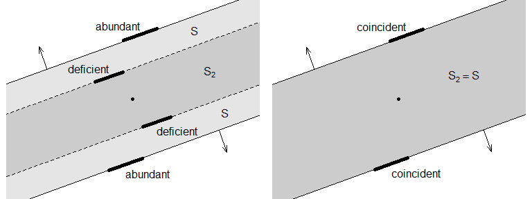

Figure 10.1

On the other hand, if a parallelogram of $S_2$ is in the boundary of the slab $\mathcal{S}$, then the two parallelograms are equal and we call them *coincident*. It means that every $z$ in this parallelogram is the image of an $x \in Q^n$ that has 2 (or 0) transitions. This is illustrated in the right side of the above figure.

To get data about the abundant and coincident parallelograms in $\partial Z$, use the functions `transitionsdf()`, for example:

```r
matgen = colorimetry.genlist[[2]]   # the CIE 1931 CMFs at 1nm step
matgen = 100 * matgen / sum( matgen[2, ] )   # it's traditional to scale so the center has Y=50
zono =  zonohedron( matgen )
getcenter(zono) ; dim( getmatrix( getsimplified( getmatroid(zono) ) ) )
```

```
##        x        y        z
## 50.00400 50.00000 50.01653
```

```
## [1]   3 340
```

```r
transitionsdf( zono )
```

```
##        transitions parallelograms     area.min     area.max   area.sum   deficit.min   deficit.max   example
## 1                2          93360 7.114460e-09 2.003446e+00 33110.4010 -1.776357e-13  1.563194e-13 {446,587}
## 2                4          12726 2.296428e-10 6.361879e-01   542.3764  9.426770e-11  2.071725e+00 {558,606}
## 3                6           6614 4.248782e-11 5.593713e-01   573.9715  2.149675e-08  9.832775e-03 {565,605}
## 4                8           1802 5.703649e-09 5.000034e-01   315.2465  4.329429e-07  5.726933e-03 {570,608}
## 5               10            758 6.674710e-04 4.727684e-01   127.2270  7.274884e-05  2.353013e-03 {572,608}
## Totals          NA         115260           NA           NA 34669.2224            NA            NA
```

The number of (simplified) generators of `zono` is $n{=}340$, indexed from 360 to 699. So the total number of parallelograms is $340(340{-}1)=115260$. Data in the first row are for the coincident parallelograms, with 2 transitions. These form the majority of $\partial Z$, with about 33110/34669 = 95.5% of the surface area. Data in the rows below is for the abundant parallelograms. More transitions typically have fewer parallelograms. The last column has an example of a parallelogram with the given transition count. For example, there are 1802 parallelograms in $\partial Z$ with 8 transitions, and the one given by generators $\{ 570,608 \}$ is one of them. This means that the line through $v_{570}$ and $v_{608}$ cuts $P$ in 8 places. Here is a plot of the point in the cube that maps to the center of the parallelogram:

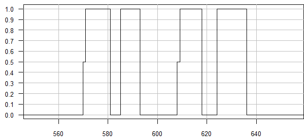

Figure 10.2

```r
oldpar = par( omi=c(0,0,0,0), mai=c(0.45,0.5,0.1,0) )
gnd = getground(  getmatroid(zono)  )
pcube = boundarypgramdata( zono, c(570,608), cube=TRUE )$pcube
xlim = range( gnd[which(0<pcube)] ) + 20*c(-1,1)
plot( xlim, c(0,1), type='n', xlab='', ylab='', las=1, lab=c(5,10,7), cex.axis=0.8 )
grid( col='gray', lty=1 )
lines( gnd, pcube, type='s' )
```

```r
par( oldpar )
```

Note that the values at 570 and 608 are both 1/2, and all the other values are 0 or 1.

The following figure is a helpful 3D visualization of *all* the abundant parallelograms:

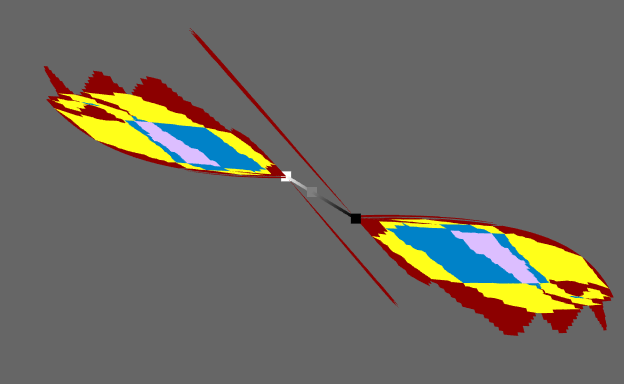

Figure 10.3

```r
library( orientlib )
user3x3 = orientlib::rotmatrix( orientlib::eulerzyx( -0.249417, 0.7116067, 2.324364 ) )@x
dim(user3x3) = c(3,3)
par3d( userMatrix=rotationMatrix(matrix=user3x3), zoom=0.35 )
plothighertrans( zono )
```

In this figure, the abundant parallelograms are color-coded following [3]; dark red for 4, yellow for 6, blue for 8, and purple for 10 transitions. The view is looking up the “neutral axis” with a black point at 0, a white point at the opposite point, and a gray point at the center of symmetry. The central symmetry of the abundant parallelograms is clear. Compare this with Figure 7 in [3].

# 11 References

[1]

ALEXANDER, J. W. On the subdivision of 3-space by a polyhedron. *Proceedings of the National Academy of Sciences* [online]. 1924, **10**(1), 6–8. Available at: doi:10.1073/pnas.10.1.6

[2]

BING, R. H. *The geometric topology of 3-manifolds*. B.m.: American Mathematical Society, 1983. American mathematical society colloquium publications, v. 40. ISBN 9780821810408.

[3]

BURNS, Scott A. The location of optimal object colors with more than two transitions. *Color Research & Application* [online]. 2021, **46**(6), 1180–1193. Available at: doi:https://doi.org/10.1002/col.22693

[4]

GÜNTHER WYSZECKI AND W.S. STILES. *Color Science : Concepts and Methods, Quantitative Data and Formulae*. Second. B.m.: Wiley-Interscience, 1982.

[5]

LOGVINENKO, Alexander D. An object-color space. *Journal of Vision* [online]. 2009, **9**(11), 5. Available at: doi:10.1167/9.11.5

[6]

MILNOR, J. and WEAVER, D. W. *Topology from the differentiable viewpoint*. B.m.: Princeton University Press, 1997. Princeton landmarks in mathematics and physics. ISBN 9780691048338.

[7]

MOISE, E. E. *Geometric topology in dimensions 2 and 3*. B.m.: Springer New York, 2013. Graduate texts in mathematics. ISBN 9781461299066.

[8]

SCHRÖDINGER, Erwin. Theorie der pigmente von größter leuchtkraft. *Annalen der Physik* [online]. 1920, **367**(15), 603–622. ISSN 1521-3889. Available at: doi:10.1002/andp.19203671504

[9]

SPIVAK, Michael. *A comprehensive introduction to differential geometry*. Third. B.m.: Publish or Perish, Incorporated, 1999. Volume 1. ISBN 9780914098706.

[10]

WEST, G. AND BRILL, M. H. Conditions under which Schrödinger object colors are optimal. *Journal of the Optical Society of America*. 1983, **73**, 1223–1225.

# 12 Session Information

This document was prepared Sun Aug 31, 2025 with the following configuration:

```
R version 4.5.1 (2025-06-13 ucrt)
Platform: x86_64-w64-mingw32/x64
Running under: Windows 11 x64 (build 26100)

Matrix products: default
  LAPACK version 3.12.1

locale:
[1] LC_COLLATE=C
[2] LC_CTYPE=English_United States.utf8
[3] LC_MONETARY=English_United States.utf8
[4] LC_NUMERIC=C
[5] LC_TIME=English_United States.utf8

time zone: America/Los_Angeles
tzcode source: internal

attached base packages:
[1] stats     graphics  grDevices utils     datasets  methods   base

other attached packages:
[1] orientlib_0.10.5 rgl_1.3.18       zonohedra_0.6-0

loaded via a namespace (and not attached):
 [1] digest_0.6.37        R6_2.6.1             microbenchmark_1.5.0
 [4] base64enc_0.1-3      fastmap_1.2.0        xfun_0.52
 [7] magrittr_2.0.3       glue_1.8.0           cachem_1.1.0
[10] knitr_1.50           htmltools_0.5.8.1    logger_0.4.0
[13] rmarkdown_2.29       lifecycle_1.0.4      cli_3.6.5
[16] sass_0.4.10          jquerylib_0.1.4      compiler_4.5.1
[19] tools_4.5.1          evaluate_1.0.3       bslib_0.9.0
[22] yaml_2.3.10          htmlwidgets_1.6.4    rlang_1.1.6
[25] jsonlite_2.0.0
```